# Multiple Hypothesis Testing!

## aka "Plenty of P-Values"

### by Zane Blanton

#### Data Scientist in Marketplace at trivago

# Standard Hypothesis Testing

- We set an $\alpha$ (False Error Rate) of 0.05.
- Thus, only five percent of null hypotheses that we test are actually rejected.
- We hope that analyses delivered in this way are for the most part are valid.

## How we hope this works

```python
total_null = 500
total_alt = 500

rejected_null = total_null * 0.05
rejected_alt = total_alt * 0.95
```

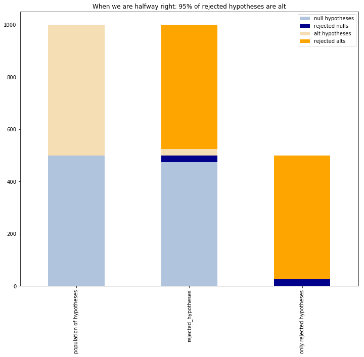

```python
plot_hyp_df()
```

## But what if we go wild?

```python
total_null = 950
total_alt = 50

rejected_null = total_null * 0.05
rejected_alt = total_alt * 0.95
```

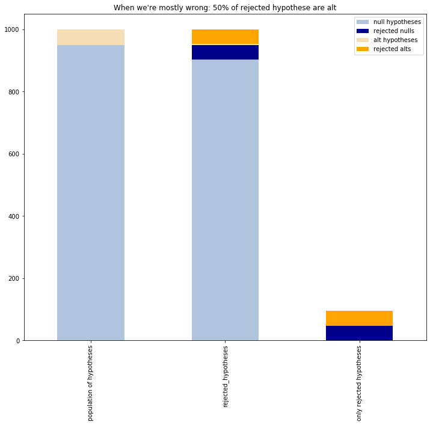

```python
plot_hyp_df_again()
```

## And where might we encounter the second situation?

[figure not shown]

## Let's make up parameters for a multiple testing situation and simulate some data

- Assume null p values distributed as Uniform(0, 1)
- Assume alternative p values distributed as Beta(1, 100)
- This assumption means that we have a lot of power, since we're nearly guaranteed to reject our alternative hypotheses at an $\alpha$ of 0.05

```python
a = 1
b = 100
x = np.arange(0, 1, 0.001)
null_distr = np.ones(1000)
alt_distr = beta(a=a, b=b).pdf(x)
```

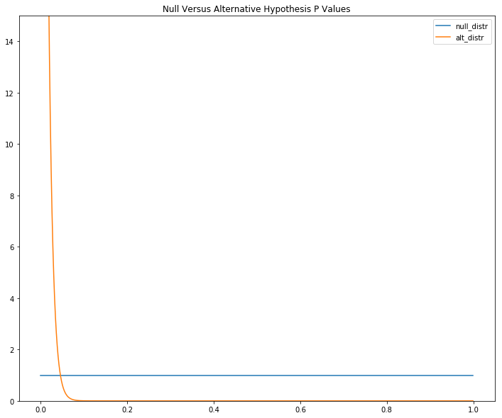

```python
plot_our_p_distrs()
```

# Let's sample some p values!

But first, let's assume that 90% of the hypotheses we are testing are null.

```python
total_null = 900
total_alt = 100
null_pulls = np.random.random(total_null)
alt_pulls = np.random.beta(a=a, b=b, size=total_alt)
```

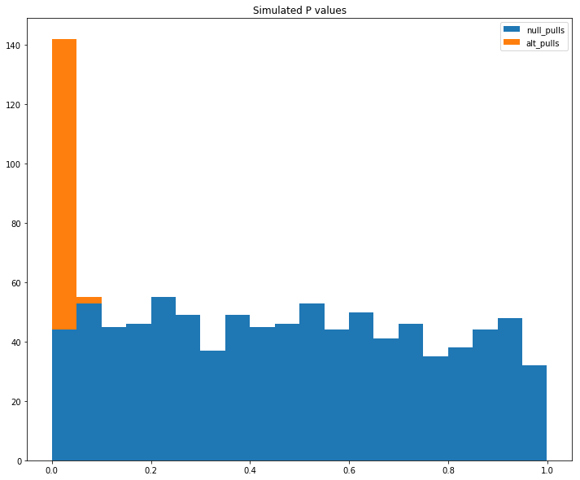

```python
plot_sim()
```

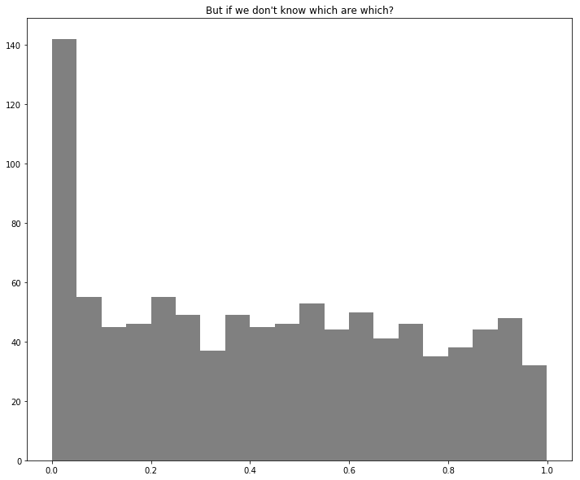

```python
plot_sim_gray()
```

# Let's use our classic method with $\alpha$ = 0.05

```python
null_pulls_rejected = null_pulls[null_pulls <= 0.05]
alt_pulls_rejected = alt_pulls[alt_pulls <= 0.05]
```

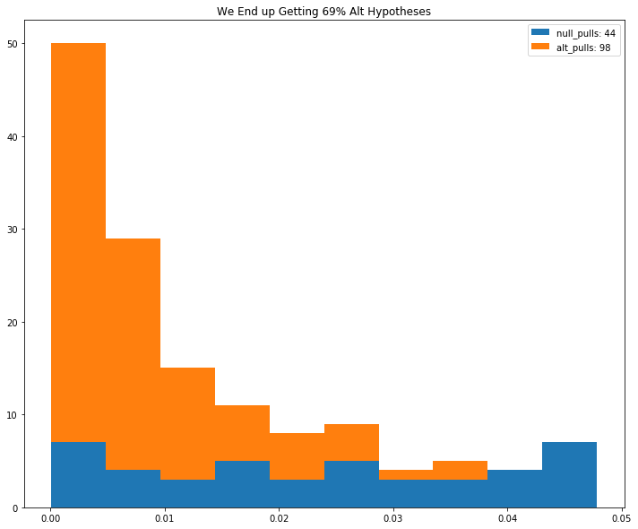

```python
classic_hyp_hist()
```

# Bonferroni Correction

### Definition of family-wise error rate (FWER)

If any null hypothesis is rejected under the null, then we consider it a false positive.

The Bonferroni correction controls FWER by setting $\alpha = \frac{0.05}{k}$ where $k$ is the number of hypotheses we're testing. In our case, this is $0.05 / 1000 = 0.00005$

```python
print(alt_pulls[alt_pulls <= 0.05 / 1000])
print(null_pulls[null_pulls <= 0.05 / 1000])
```

```
[]
[]
```

```python
print(alt_pulls[alt_pulls <= 0.10 / 1000])
print(null_pulls[null_pulls <= 0.10 / 1000])
```

```
[  9.82946677e-05]
[]
```

But somehow this is unimpressive

# If only there were another way...

# Controlling False Discovery Rate (FDR)

We can set an $\alpha$ control on the expected proportion of null hypotheses in the set of hypotheses we reject, known as the False Discovery Rate.

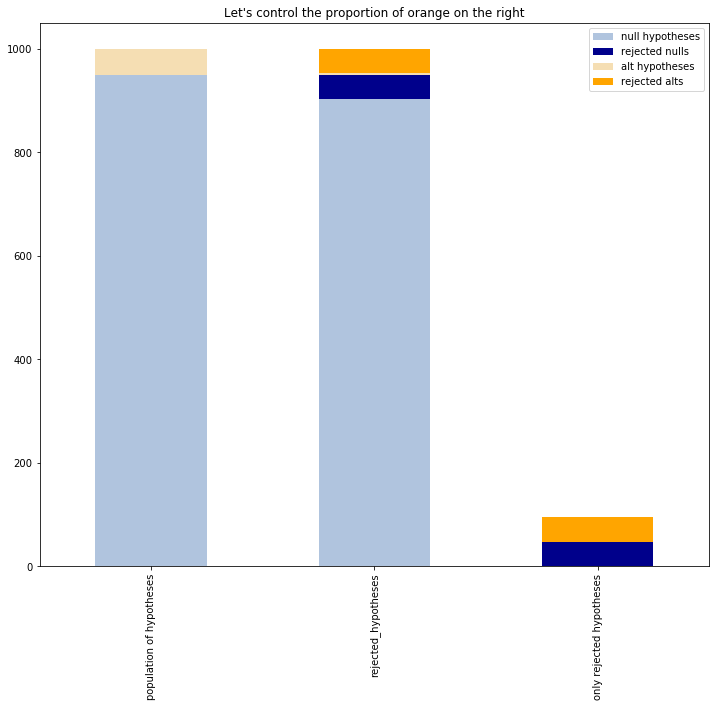

```python
plot_hyp_df_fdr()
```

# Benjamini-Hochberg Step-up Procedure:

1. Sort all null hypotheses. The smallest p value is $p_{(1)}$, the second smallest is $p_{(2)}$, etc.
2. Set an FDR control $\alpha=0.10$
3. Then, find the largest $k$ such that $p_{(k)} \le \frac{k}{m}\alpha$.
4. Finaly, we we reject all null hypotheses $p_{(1)}, \dots, p_{(k)}$

We will accept this procedure as magic, but for those of you who are curious, here's a link to the proof: https://statweb.stanford.edu/~candes/stats300c/Lectures/Lecture7.pdf

# Now, let's apply this to our data

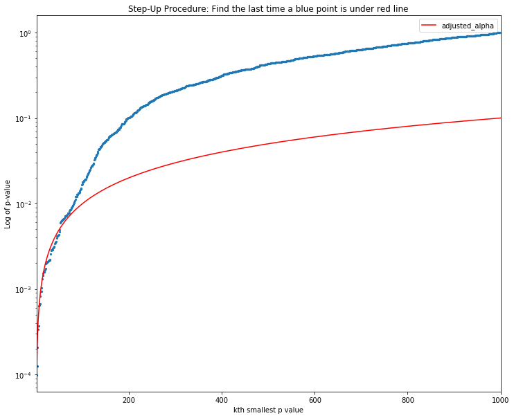

```python
plot_stepup()
```

```python
print(p_values_rejected)
```

```
    case         p  adjusted_alpha   k
0    alt  0.000098          0.0001   1
1    alt  0.000126          0.0002   2
2    alt  0.000207          0.0003   3
3    alt  0.000334          0.0004   4
4    alt  0.000367          0.0005   5
5    alt  0.000632          0.0006   6
6    alt  0.000642          0.0007   7
7    alt  0.000675          0.0008   8
8    alt  0.000819          0.0009   9
9    alt  0.000941          0.0010  10
10   alt  0.000944          0.0011  11
11   alt  0.001036          0.0012  12
12  null  0.001305          0.0013  13
13  null  0.001430          0.0014  14
```

[output cut: 37 more lines]

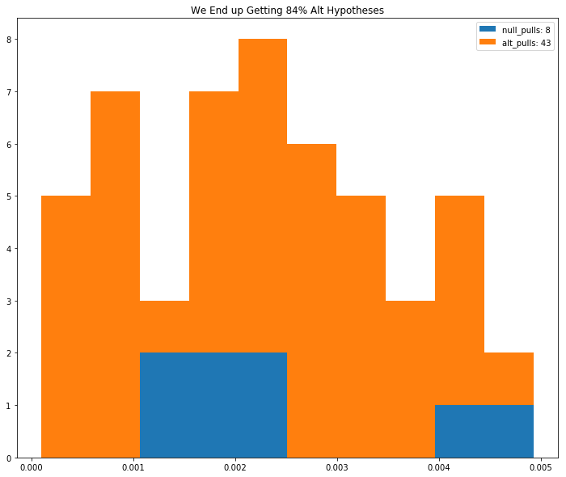

```python
plot_stepup_hist()
```

# Wrap-Up

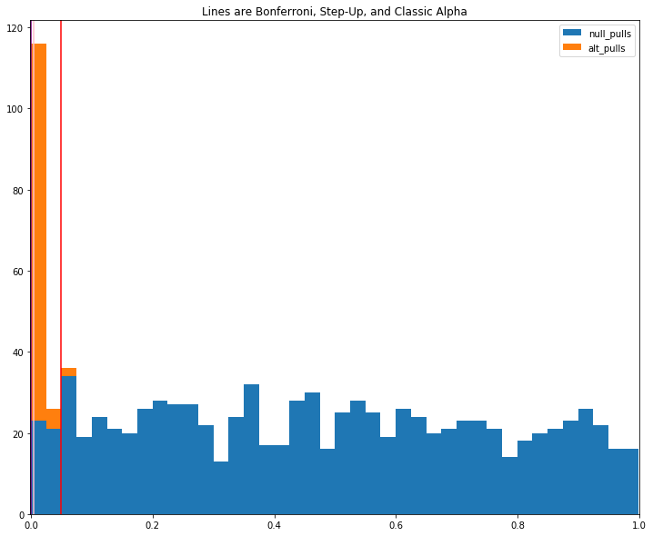

```python
plot_all_criteria(xmax=1.0, bins=40)
```

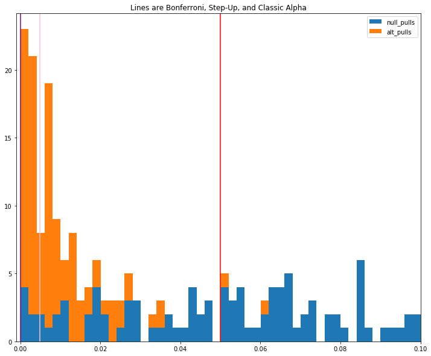

```python
plot_all_criteria(xmax=0.10)
```

# Wrap-Up

- Traditional hypothesis testing controls our false positive rate, the rate at which we reject null hypotheses.
- Also discussed a Family-Wise Error Rate (don't make even one mistake!) and looked at the Bonferroni correction
- We also discussed a False Discovery Rate, which is the proportion of null hypotheses in the pool of rejected hypotheses, and looked at the BH Step-Up Procedure to correct for this.
- If you had a representative set of labelled hypotheses, you could set up a loss function and optimize your cutoff based upon it

# Final note on Dependence of P Values

- FDR methodology can be extended to deal with dependence among test statistics.
- In the positively correlated case, our current controls are sufficient.
- For the negatively correlated case, we have to reduce our p values further.
- Bonferroni adjustment covers all cases.

Of course, there are lots of other ways to deal with this problem.

Feel free to try different methods until you get the results you want! (joke)

```python
help(multipletests)
```

```
Help on function multipletests in module statsmodels.stats.multitest:

multipletests(pvals, alpha=0.05, method='hs', is_sorted=False, returnsorted=False)
    test results and p-value correction for multiple tests


    Parameters
    ----------
    pvals : array_like
        uncorrected p-values
    alpha : float
        FWER, family-wise error rate, e.g. 0.1
    method : string
        Method used for testing and adjustment of pvalues. Can be either the
        full name or initial letters. Available methods are ::

        `bonferroni` : one-step correction
        `sidak` : one-step correction
        `holm-sidak` : step down method using Sidak adjustments
        `holm` : step-down method using Bonferroni adjustments
        `simes-hochberg` : step-up method  (independent)
        `hommel` : closed method based on Simes tests (non-negative)
        `fdr_bh` : Benjamini/Hochberg  (non-negative)
        `fdr_by` : Benjamini/Yekutieli (negative)
        `fdr_tsbh` : two stage fdr correction (non-negative)
        `fdr_tsbky` : two stage fdr correction (non-negative)

    is_sorted : bool
        If False (default), the p_values will be sorted, but the corrected
        pvalues are in the original order. If True, then it assumed that the
        pvalues are already sorted in ascending order.
    returnsorted : bool
         not tested, return sorted p-values instead of original sequence

    Returns
    -------
    reject : array, boolean
        true for hypothesis that can be rejected for given alpha
    pvals_corrected : array
        p-values corrected for multiple tests
```

[output cut: 20 more lines]

```
    All procedures that are included, control FWER or FDR in the independent
    case, and most are robust in the positively correlated case.

    `fdr_gbs`: high power, fdr control for independent case and only small
    violation in positively correlated case

    **Timing**:

    Most of the time with large arrays is spent in `argsort`. When
    we want to calculate the p-value for several methods, then it is more
    efficient to presort the pvalues, and put the results back into the
    original order outside of the function.

    Method='hommel' is very slow for large arrays, since it requires the
    evaluation of n partitions, where n is the number of p-values.
```

## *And now it's Question Time*